# Leadership Map

George Bernard

# 1 Executive Summary: One Page Leadership Map

## 1.1 Life Values and Goals: A Life of Service to my Tribe

- To my friends, family, and to the world large, finding my own fulfillment in helping them to chase theirs
- Be stronger hearted, more capable of fighting for what I believe in
- Make a ripple of generosity and helpfulness from the people I help

## 1.2 Great Job = Challenge + Community

- Intellectually Challenging, to always be learning and applying new knowledge with like minded people
- Sense of camaraderie and unity of purpose, to have a fellowship and sense of community with my coworkers
- Flexible in when and where I work, so long as I am sufficient in accomplishing my goals
- What I do either helps others or enables me to help others.

## 1.3 What I'm good at

- Raw enthusiasm for learning, critical feedback, and personal development
- Extroversion and genuine interest in the well-being of others.
- Large sense of responsibility for group settings
- Personal resilience to difficulty, enthusiasm in the face of discomfort

## 1.4 What I suck at

- Interpersonal soft skills (e.g. empathy, group dynamic awareness)
- Discipline to pursue goals that don’t itch curiosity (i.e. not fun)
- I crave positive attention and often make group situations about me
- I often neglect my morals to fit in with the crowd or personal friends better

## 1.5 How I will be better eventually

- Build moral habits, make doing the right thing instinctual vs. intentional
- Find and stick by those communities that most embody my values and challenge me to be more ethical
- Build the moral courage to act on my values outside of those communities and in the real world.

## 1.6 How I will be better right now

- Poll my moral beacons and gurus on their advice on how to be better
- Sit with my own failures so that I may more deeply understand their source

## 1.7 Big Questions

- How do I muster moral courage?
- How do I build discipline?

# 2 My Story

## 2.1 Childhood: Setting The Stage

When I was born, my mom was scared to give me up. She was deeply worried that the world would hurt me, that she needed to protect me. Her Douala (a birth assistant similar to a midwife) said to her, "No, he will protect you"...

These are the words that still echo in my life, the guiding perspective that I should take care of my friends and neighbors, that I should live a life of service to others.

### 2.1.1 Family Traits

My personality, like most I assume, is deeply influenced by that of my family. Both my parents drive me to develop my:

- Wit and Humor
- Charisma
- Generosity
- Worldliness

From my father, Collier, I most admire and try to emulate his:

- Nerdy love for math and science
- Diplomacy and desire to please others
- Enthusiasm

From my mother, Patti, I most admire and try to emulate her:

- Intense care for my family and friends
- Extroversion and a willingness to interact with everyone at their level
- Raw moral courage and strong heartedness
- Drive to succeed
- Candor and Honesty

From my most older sister, Katy, I most admire and try to emulate her:

- Drive to succeed
- Intensity
- Steadfastness and commitment to her goals
- Kindness
- Intelligence (which is enormous but she would never admit this to you)

From my less older sister, Alexi, I most admire and try to emulate her:

- Empathy
- Thoughtfulness
- Easygoing nature
- Creativity

These are but windows to the multi-faceted people they are, but I am deeply grateful for the impact they have had and continue to have in my life. They are my mentors, friends, and confidants. I would not be half the person I am today without their influence.

### 2.1.2 Primary School

In primary school, my parents placed me in an international school, the British School of Houston. There I came to learn and incorporate the community values there.

- Politeness and Gentility
- Self Deprecating Humor
- Penchant for the absurd
- Family loyalty

These norms carried me through my childhood, with a special focus on humility. I was (and still am to be clear) overweight and out of shape. This lack of physical fitness could be seen in my chubbiness and my terrible performance in physical education classes. I was consistently the last person in every test of strength or endurance. This is not to say you should pity this child, as I only bring it up to suggest how radically okay I was (or learned to be) with the state of things. I had the worst times in any running event, being forced to run and doing terribly in front of the entire school on sports day (an all school competition day). I was by no means traumatized by this, it's more that I learned firsthand I would not excel in all things.

This is the essence of my humility. I will not be the best in all things. I will not even be the best at any one thing. There are always people who are better. The key is in understanding yourself as imperfect. Radically accepting who you are, and striving to do better in what ways you can. I knew that I was unfit, but that it was not a character failure, it is a stepping stone on the way to being better. It just took this fat kid "running" a 100 m sprint in several minutes to learn it.

## 2.2 Adolescence: Building Character in "The Woods"

At the age of 14, with both of my older sisters having started their college journeys. My parents wanted to move us to Colorado to better help with their quality of life and improve my Dad's allergies.

### 2.2.1 Anti-fragility: Resilience built through Adversity

I was enrolled in *Colorado Rocky Mountain School*, and that August I started in the Wilderness Orientation program. This was without a doubt the hardest physical challenge of my life. For wilderness orientation, we are taken out in groups of 7-9 incoming students and 2 faculty members and 1 student leader. The first three days were spent doing trail maintenance. The last 7 were spent backpacking in the remote Colorado wilderness.

Keep in mind, I was a fat kid from Texas. We drove from air conditioned box to air conditioned box. I had never been challenged physically like this at all. I could count on one hand the hikes I had done beforehand. To this day, I am deeply ashamed of how the leaders needed to ferry my pack so that I could simply make it up the hill unweighted. On the last day of the trip, water had dripped through the tarp (that I had poorly set up myself) onto my chest as I slept. I woke up cold and broken. We were then promptly forced to get out of our sleeping bags, wake up and tackle the new and final day of the trip. When I finally got out of my bag, I was bawling. My group was visibly worried for me, crying as I laced up my hiking boots. I balanced out again, and this same story played out a few more times in my outdoor experiences. Later that semester, I was in a canoe with a classmate failing miserably to ferry our boat across only the most moderate of rolling river. I cried out that I was trying my hardest, and it wasn't good enough.

The thing is, after you are broken so many times by intensely difficult experiences, you learn to handle it. You learn to roll with the punches. After enough of roughing it in the woods, you learn to get rougher. Nasim Nicholas-Taleb writes about the concept of **Anti-fragility**, when a system performs better under stress. Discomfort forced me to become more resilient. I have felt at my best in a stressful moment on a backpacking trip. I have felt clarity when I have to make our team not lost, administer aid for a hypothermic trip member, or cook dinner for my crew so they can get in the tent and warm up. There is a unique energy to these make or break moments. In a modern world of absolute luxury (at least for those with my privilege) you break out of the "first world problems" by leaning in to the uncomfortable and difficult in the woods. These experiences calibrated what I view as truly stressful, and made into a more emotionally stable person.

### 2.2.2 Lessons from Antiquity: Lao Tze and "The Way"

Over the summer before my sophomore year, my dad handed me a translation of the Tao Te Ching ("Book of the Way"), a work of Chinese poems that worked as a textual basis for the Taoist tradition.

The primary themes are all about stepping back, listening to the world, and acting along the path of least resistance. There are amazing sections which still give me chills to this day.

Excerpts like this from Stephen Mitchell's translation,

> 8  
> The supreme good is like water,  
> which nourishes all things without trying to.  
> It is content with the low places that people disdain.  
> Thus it is like the Tao. In dwelling, live close to the ground.  
> In thinking, keep to the simple.  
> In conflict, be fair and generous.  
> In governing, don't try to control.  
> In work, do what you enjoy.  
> In family life, be completely present. When you are content to be simply yourself  
> and don't compare or compete,  
> everybody will respect you.

and,

> 13  
> Success is as dangerous as failure.  
> Hope is as hollow as fear. What does it mean that success is a dangerous as failure?  
> Whether you go up the ladder or down it,  
> you position is shaky.  
> When you stand with your two feet on the ground,  
> you will always keep your balance. What does it mean that hope is as hollow as fear?  
> Hope and fear are both phantoms  
> that arise from thinking of the self.  
> When we don't see the self as self,  
> what do we have to fear? See the world as your self.  
> Have faith in the way things are.  
> Love the world as your self;  
> then you can care for all things.

made me focus inward and critically examine my self. You can feel the humility and presence in this. This book inspired me to be more humble, to listen first to understand then to speak. To see my own path in this period of change that is puberty. This narrative is fundamentally different than the mainstream western ideals. Seek not success, or, better yet, seek not, for you may find success as a side effect of living the good life.

These poems still form the basis for my ethical traditions to this day, and, while are deep faults in the gentle approach, as a growing boy, with culture that leans towards trying to be a **Big Man**, it was a deeply useful moral reference text for me.

### 2.2.3 Lessons from Antiquity: Ancient Greece

The liberal arts program at my school had a love affair with the classical period. I've included some of the lessons from then that have most served as guiding models for my behavior.

#### 2.2.3.1 Arete: Fulfilling Your Potential

The pre-Socratics had this beautiful idea of measuring virtue. They knew that people were born in fundamentally different circumstances. They knew that an enslaved serfs could not rise to the same heights as landed gentry. They defined Arete as this proportion of your own potential that you achieve. If you have less potential than someone with more privilege, but you actualize all of your potential and they actualize half of theirs, you have cultivated more virtue.

Arete introduced concepts of privilege and inequality in the modern world. It allowed me (a white cis-het male) to avoid the pitfalls of wondering why other people weren't doing as well as I did. Much like Ben Sands spoke at the 36 hours at Duke event, We would much prefer someone to work their way out of an impoverished slum and change the world, but the barriers to that are so fundamentally high, that we do a disservice to those people by not capitalizing on our own potential to help.

I interpret this now as a call to action for those who won the birth lottery to be placed in my socio-ethno-political class. If we do not actualize our potential in the service of others, if we do not lower the barriers so that others may actualize their potential than what good can we say we have done with our own potential.

#### 2.2.3.2 Socrates' Moral Imperative: When To Be The Biting Fly

We come to the trial and death of Socrates. In his defense, before the court of Athens, he said that he himself was the biting fly on its rear end. That he was spurring the people of Athens to be better, by asking the hard questions, by being a deeply annoying person, by questioning and laying bare their fundamental beliefs. He was so stubborn, that rather than apologize and pledge to bother people less, he leaned in and took the death penalty, a glass of poison hemlock.

Sometimes I feel like the biting fly, and sometimes I feel like the Horse's buttock. I'm no Socrates. He alienated so many of his countrymen. To this day I still wonder when to bite down on someone's idea and when to let it go. Lao Tze got to me first, teaching me to be gentle and bend rather than steadfast and bite. Yet I often wish I had the moral courage of Socrates to so stand by his principles as to throw his life on the line.

### 2.2.4 Lessons from Antiquity: Roman Stoicism

The hip new thing in Silicon Valley is Roman Stoicism. I don't want to pull a bearded hipster and say "I liked it before it was cool", but I was lucky that my high school education included reading and interpreting texts from that period. Hopefully some of these anecdotes will elucidate how I learned my behaviors.

#### 2.2.4.1 Life Is Long If You Know How To Use It - Seneca

In his work, Seneca makes the connection that just in the way that money, when spent wisely and frugally, lasts longer so too does the time in our days. We must wisely and deliberately spend our time throughout our days so that we may do the most with them. It seems obvious now, but to sophomore year George, these words were gold. He wanted so much to improve, and so he learned to seize the day and do that which he would most benefit.

This had a shadow side however. Living deliberately is not cost free. It takes great effort to keep yourself accountable and taking advantage of every moment. And when I made it to University this proved to be unsustainable. There were simply too many things. I was splitting my time so widely that I lacked depth in doing any one thing well. I needed to reign in and take a deeper look at this lesson. Just in the same way that we only have so much influence, we should focus on what our time is valued at, and fill it not only with the most *productive* but the most *fulfilling* activities. Choose to spend your time with friends knowing the impact of your choice. Live with presence, i.e. awareness of the present, to maximize your time here on earth.

#### 2.2.4.2 Wake and Do The Work of Man - Marcus Aurelius

My history teacher, Dave Meyer, would often read a passage from Marcus Aurelius' "Meditations".

> I. In the morning when thou findest thyself unwilling to rise, consider with thyself presently, it is to go about a man's work that I am stirred up. Am I then yet unwilling to go about that, for which I myself was born and brought forth into this world? Or was I made for this, to lay me down, and make much of myself in a warm bed? 'O but this is pleasing.' And was it then for this that thou wert born, that thou mightest enjoy pleasure?

We learn that even Marcus Aurelius, leader of the Roman empire, had trouble getting out of bed in the morning. Questioning his purpose and why he would struggle to cast off his blanket. He contends that it is his nature to work, and that failure to work in the morning is a failure to retain integrity (self alignment with his own nature).

Often when I am procrastinating an assignment, or hesitant to get out of bed, the motivation I need to here is not that my day will be easy, but that it will be truly difficult and I must complete it anyway. That day I woke up wet and weary on my Wilderness Orientation, what got me out of bed was knowing that in order to end the trip, I needed to get up and get going.

### 2.2.5 Lessons from Modernity: Positive Existentialism

Although both my parents believed in God and had been raised as Baptist and Catholic respectively, I was not raised in a religious tradition. I had never had that proclivity for existential crises that many others struggle with when faced with a lack of objective meaning in their lives. I knew that I would die, but I have always been agnostic, unsure of what lays beyond, preferring to act as ethically as I can and roll the cosmic dice.

I was lucky that in my senior year, before I had really doubled down on any existential dread, I was exposed to Eastern and Western philosophical traditions in respective classes. These classes were offered within the same semester, both taught by the same teacher, Mark Clark (who was also one heck of a cross country skier). After a separate curriculum in the two classes for the first two thirds of the semester, both classes funnel into the synthesis of eastern and western thought into the modern eras existentialist literature.

There was something so motivating, so empowering, about hearing how there was no objective path, no objective meaning. It was up to me to decide for myself my best way to live my life. These classes helped me to formulate my worldview as a kind of deeply positive nihilism. Combined with the curriculum of Roman stoicism, I became a deeply happy pessimist. Camus showed me the absurdity of life, and I chose to laugh and get on with it. Sartre showed me the radical freedom I had in my life. Simone De Beauvoire showed me how to be comfortable and embrace the ambiguity at the heart of life. There's no fundamental bedrock to base our morality on, but it didn't stop me from being moral, only called upon me to make my own morals and act in the way I think is best.

### 2.2.6 Lessons from the Community: Friends That Promote You

Starting high school, I found the friends that were immediately available. This section is not to make moral judgments about them. My two friends, names changed, Tom and Jack, I had met on wilderness orientation. They were very fun people and I loved spending time with them. I cared about them and they cared about me, yet I feel like the dynamic left a lot to be desired. I often felt like the funny whipping post. I felt like they often intentionally bothered me to get a rise out of me. By sophomore and junior year, I had grown tired of trying to rely on any deeper connection with them. Around sophomore year, I had gotten to know my now best friend, Tanner. What was different about my relationship with Tanner was how he promoted me. I felt like my goals were his goals and that made his goals my goals. To this day we are deeply loyal to each other. This experience, while not really dramatic, helped me isolate that I should not be "lazy" in finding friends. That I should seek out and work to surround myself with people that have my best interests in heart. Not to say I cannot be friends with people like Tom and Jack, we still talk and have fun together, but that I should not base my worth in their evaluations. I found a confidant in Tanner, and to this day that relationship has been worth it's weight in gold.

### 2.2.7 Lessons from the Community: Accountability To The Collective

My school was founded by three people, deeply influenced by Quaker thought. Every week we had all school meetings in an up-cycled barn. These would break down into:

1. Decisions
2. Apologies
3. Thank You's and Shout Out's
4. Announcements

The focus was on putting the community above yourself. That even if you failed you can still be held accountable and helped back along the noble path by your peers.

Our school nurtured a community of interdependence. Our day broke down into three categories: school, sport, and work. In sport, in our outdoor excursions, we would need to rely on each other to belay us when climbing or throw a rope and catch our kayak when we bail out of our boats in a rapid. In work, we all pitched in to improve and maintain our campus; I helped maintain the schools fleet of activity buses, and my friends worked blowing our cafeterias glassware or throwing the clay in our communal mugs; Some even worked in the kitchen preparing our meals, or in the garden supplementing our diets with fresh produce. It was, in no uncertain terms, quite the hippie-dippie commune. We relied on each other at that school, and it set me on the path towards serving my community.

In our classes, we addressed teachers by first name, recognizing them not just as leaders but as community members. Classes were taught in the Socratic tradition, where students were encouraged to speak up and ask "dumb" questions. Those same teachers took us kayaking, or helped us garden, or played music with us at all school concerts. This was instrumental in my later ability to relate as friends to adults, as well as give me the baseline confidence to pipe up and ask when I don't understand.

## 2.3 University: A Sobering Climb towards Maturity

Coming to Duke was so fundamentally different than high school, but at the same time played to my strengths. I came to Duke, and was lucky enough to go on the PWILD August Trip, a student led backpacking trip for incoming freshman. It was like the synthesis of my CRMS experiences while being surrounded by deeply thoughtful and intelligent people.

### 2.3.1 Success At Duke

I hesitate to admit it in writing, but my communities and close ones have deemed me "smart". What does this mean? To me it means that I have a winning combination of radical enthusiasm for learning, the ability to synthesize new ideas, and break down problems into small easier to tackle problems. This has allowed me to attain fairly substantial academic success at Duke without destroying myself. I still spend many a Friday night in the library, but I enjoy it on it's own merit, not for a grade.

When I got to Duke my freshman year, I found that I excelled in my classes with, to me at least, moderate effort. I was incredibly lucky to find a domain, computer engineering, that both interested me greatly and I in turn was good at.

### 2.3.2 Failure in Success: Losing Humility

At Duke, I lost some of that humility I had spent my younger life building. I let this academic success get to my head. I grew cocky and quietly nurtured a superiority complex. For lack of better words, this was stupid.

After feedback from others (once again the importance of community call outs), I realized what I had lost. I am only now on the path toward regaining some of this honest self awareness of my place in the grand scheme of things.

### 2.3.3 Moral Development

Let me say that I was, and still am, deeply problematic. I only have the words to describe my own immaturity at this point of my life from the work I have done and others have done alongside me. On PWILD, on the first night, I told a series of dirty jokes that were deeply inappropriate and must have made my fellow crew deeply uncomfortable with me. Thinking about it now, I feel deeply ashamed of myself for this. The trip went on, and I was exposed to the struggles that my fellow crew had. On the tail side of the trip, I had made a misogynist and objectifying comment about a "Wild Women's Retreat" event we were passing by, and a staffer called me out for it. I couldn't find the words to respond. They were right, and I was being hurtful. I sat in silence and licked my wounds. This was the start of my change for the better, but even getting better cannot erase the past. When I think about how trash I was and what progress I have made it only motivates me to be even more thoughtful, kind, and nuanced in my language.

### 2.3.4 Being Criticized: The Importance of Community Call Outs

For me, this is the essence of why being called out is exactly what I needed to spur me towards being a better person. Let's be honest, someone needed to set me straight. I wish that I could have come to this realization myself, but I lacked the tools. Someone else had to put in the emotional labor of confronting me. These people I, to this day, deeply admire and thank for their work in making me a better person.

It's true for so many men of my own age, and I was only lucky enough to be paying attention at those moments of ripeness. The most moral progress and change I have made come from those evenings where, following a call out earlier that day, I was forced to entertain the idea of my misgivings. I was only lucky enough to be open to alternatives. The combination of my own humility, with the (far more important) call to be better by those I admired in my community helped me to that sobering climb towards maturity.

### 2.3.5 Duke Men's Project

In my junior year at Duke, I joined the Duke Men's Project, a brand new (at the time) initiative to make a community of men who would help teach each other to be more moral and aware people. We met weekly at the women's center on east campus to discuss issues underpinning systemic inequality and intersectionality. It was a tremendously useful learning experience for me.

At this point I have to take a quick aside to talk about my issues with the word "woke". When we call someone woke, I feel that we are turning awareness into moral points. By splitting the world into people who are woke or not, we make two mistakes: people who are woke are sufficiently good and do not need to continue learning, and people who are not woke know less about hardship and struggle than those who are. "Woke" is fixed mindset. To say that we are woke is to lose the fact that we are all crooked timber, stumbling towards being better. It's like a commoditized moral license. Once you are woke, then you can sit back and relax. Awareness is useless without action. Guilt is useless if it does not spur you to change the structures that you feel guilty about. Just because we are good in one area, gives us zero free passes in other areas.

I bring this up because I feel that, even as we tried for this not to happen, the Men's project encouraged ally-ship as an identity. That now that we've done the Men's project, we were woke and everything was amazing. The Men's project gave me the words and perspective to only start the path towards being a better person. It was the first step on a never ending personal journey towards being better and acting better, by helping those people who are most hurt by these power structures, and leveraging our privilege to tackle them.

I am not woke, I am deeply problematic on a daily basis. It's not okay. Every day I try to be better, and every day I stumble.

That has been my moral development, embracing that I am crooked timber, and embracing the struggle to not only have more moral beliefs, but more moral actions as well.

# 3 Life Mission

## 3.1 Establishing the Ripple

I am not a spiritual person. It's not immediately clear to me what happens to us when we die. If we are judged for our actions, how am I to live such that Anubis measures my heart lighter than a feather? If we are not judged, then what drives me to live the good life. If there is no judgment, then I should pursue my own goals ruthlessly and selfishly. I am reminded of the words of Rabbi Hillel the Elder

> If I am not for myself who is for me?  
> And being for my own self what am I?  
> If not now when?

We tread a fine line with our time in this world, between acting in the service of ourselves and acting in the service of others. My actions, if they are ethical, should not be because of a fear of judgment or desire of heavenly reward. My actions in the service of helping others and being true to myself must be justified by a consistent goal.

The key to all of this is in my **ripple**. The benefits I make on this world, I hope, will last in the signal of kindness of others. There will come a day when my name will be forgotten, everyone I know long dead, but the people I help and the people they help and they help will continue. My benefit to the world, my *raison de etre* is in the ripple of goodness that I will create to my highest ability in my own sphere of influence.

### 3.1.1 Focus on Community

I live in the domain of the practical and the human. I want to be realistic about the benefit I can make in the world. This does not mean I should artificially limit the scope of my benefits, but that I focus on helping those within my sphere of influence.

One of my life goals is to have a deep connection with my tribe. I don't mean this in a self secluding way. The connotation of focusing on your community can come across as a dog-whistle for putting your own people first. When I say tribe I mean a responsibility to my people across ethnic, class, religious, and political lines. I want to seek out those who challenge me to be better and think better. I want to make a place in my life for those people, and I want to help them achieve their goals and to feel loved by their tribe in turn.

### 3.1.2 Effective Altruism

Tempering this focus on the immediate community, we must see our ability to act on the global scale. Our world is incredibly connected, and this has been amazing for seeing the way that people around the world live. This has also shown us the dire straits that many people in this world live in. We often lose our will to act, to overcome the bystander effect, when we are so far away from the problems that people face. Simply put, we cannot live in our progressive western democracy, go to work in literal towering crystal spires, and constantly think about "starving African children or whatever".

There is huge cognitive dissonance here. If it meant getting our shoes dirty, we would save a drowning child. If it meant getting on a plane and flying across the world, we would still save a drowning child. From both of these toy examples we see that the duty to act is always there, regardless of moderate personal damage (ruining clothes) or distance (flying there). How do we get from the high level ethical breakdown in which we are honor-bound to act, to what is implemented as fundamental apathy?

Don't get me wrong, I am not condemning the very human focus on the local over the global, but one of my personal goals is to act efficiently in the service of global issues. Ergo, my life mission adds two intertwined goals. First, I want to donate large amounts of money to extremely effective charities (malaria and schistosomiasis initiatives), and, second, I want to share this approach to charity, that we should prioritize giving to extremely effective charities and that we have a duty to act in what ways we can.

## 3.2 Becoming a Craftsman

My last main goal is more amoral. I get pleasure out of making cool things. I take pride in the things I make. I have that peculiar affliction that I am good at, and deeply love, being an Engineer. It comes back to that Greek idea of Arete, I want to maximize my potential in this direction. I want to be the best Engineer I can be. Solving cool problems for smart people.

I am a toolmaker. I seek to build the tools that enable others to maximize their potential. In this way, I also establish my ripple. I want to smash the barriers that people have by enabling them to take advantage of humankind's shared incredible computational power. A life of service as a humble toolmaker, is a life I will not regret.

# 4 Success, Happiness, and Meaning

## 4.1 Why are these separate?

With so much discussion of the fundamental problems of being human, it is easy to focus on semantics, pinning down the meanings of words. How many times have my classmates stopped our teacher, Tony, and asked him to "define this word you're using, exactly". The problem is fundamental to language and more exposed when we try to talk about abstract but very personal subjects. Success, Happiness, and Meaning are all inextricable. Even these words we use only crudely set a first order approximation of the problem domain. If words and models are our maps and the ground truth of our desire is the territory, it is painfully obvious that the map is not the territory. I choose these three categories as the brute separation of this territory, to be holistic in this discussion will muddy the waters (if they are not already fevered ramblings).

## 4.2 Success

### 4.2.1 What is Success?

Success is the feeling we get when we take pride in the fruit of our labor.

As we've covered in class, a sufficient second order approximation of success can be in the following components:

- Happiness
- Achievement
- Significance
- Legacy

"Now wait a minute George", you might ask, "Why is happiness here and also covered later. That seems redundant." And to that I say that you're right... kinda. Happiness is a component of success, but in this domain it is focused on the element of enjoying the fruits of your work. The tomatoes you grow yourself always seem to taste better to you, but could honestly be replaced by store bought and anyone else wouldn't notice.

Achievement is how the success feels in a more visceral sense. It is the feeling of pride when you make it to the summit. Even if the view is obfuscated by fog, even if it is frigid, you can't help feel a sense of satisfaction from conquering this mountain. It is the feeling of **winning**.

Significance is that benefit that your success has to your tribe. How much profit did your project produce for the company? How fulfilling is it to see that student you helped turn around and ace her computer architecture midterm?

Legacy is how your success lasts. When you create your sculpture, your magnum opus, is it made of q-tips and twine? or wrought steel and hard stone? How will your success survive and thrive? We want our successes to not be destroyed in front of us. We want the code we write to be a pivotal benefit to a system that will keep chugging long after you may have left the company.

### 4.2.2 How do you measure it?

We can thus measure our success more easily by measuring the constituent components.

We measure achievement by how many of our goals we accomplish, by how difficult it was to accomplish them, and comparing them to the goals of others.

I'll focus on measuring happiness later, as much of that discussion applies here.

Legacy and significance are harder nuts to crack. You can imagine why the average Duke student may not focus on these as components of her success. They're far less *real* to us. They require a worldly wisdom to see as products of our labor.

Measuring significance is often not up to us, but on the people who we work for. The appreciation of the people that our work benefits us set the terms for seeing our actions' significance.

Our legacy is not something that we can see moving forward, these dots are only connected looking back on our life's random walk. Legacy is like concrete. It gets stronger the longer it has set, reaching peak strength years after the pour. The roman sewers and aqueducts were lasting success, but we know this only long after their society collapsed. Time has the final word on our legacy.

### 4.2.3 Why chase it?

Why should we chase success? Is it that warm feeling, that hedonic motivation that makes us search out and carve our success into the mural of human civilization. I feel at a loss for words how to describe this. I want to have some higher reason for my craving success. The materialistic explanation is all I can fall back on. The stupid, beautiful, and simple answer is that we chase success because it feels good. Being successful means surviving the night and finding a good mate. Success is therefore a key fuel in our motivation engine, but success alone cannot drive us forever.

## 4.3 Happiness

### 4.3.1 What is it?

Happiness can, too, be broken up into sub-components:

- Joy is that immediate pleasure. Those butterflies in our stomach. The overwhelming sense of ecstasy.
- Contentment is that slow burn of gratitude. The sense of rightness and harmony in the world.

### 4.3.2 How do you measure it?

The simplest way to measure your happiness is to count the frequency of *butterflies*. It is that fire in your belly that speaks to you. It does lead to a bit of experimental error, for when we look for the ways that happiness appears in our life, we open ourselves to more of it, overestimating its base occurrence.

It is easy, for most, to recognize ecstatic moments, but it is oft harder to recognize effective contentment. The feeling of being more than alright with the state of our world is fleeting if you are so focused on **The Next Big Thing**. To be content, an atomic component of happiness, is to be in deep gratitude to the circumstances of our life, both those that we have worked to achieve and those we had the raw luck to be given.

### 4.3.3 Why chase it?

For the same reasons that we chase success, we chase our happiness. Happiness is more difficult to produce than success however. Where we can work to chase success and be rewarded, chasing happiness often has the exact opposite effect. Happiness is an occasional beneficial side effect of chasing success, but it can also open itself up to you when you least expect it. If anything, happiness is the heat produced by our motivation engine burning success and meaning in different ratios.

## 4.4 Meaning

### 4.4.1 What is it?

Paul Tillich, in his seminal work on the phenomenology of religion "The Dynamics of Faith", spoke of our religious motivation engine. Humans crave ultimate fulfillment, to do so we engage with our ultimate concern and the risk that our concern is idolatrous (i.e. worshiping a false idol and receiving no such fulfillment). Meaning is our fulfillment produced by our success.

On first glance, it seems that meaning could be represented by the success components of Significance and Legacy. To that I say once again, you're right... kinda. They are in the same territory, but something about meaning cannot be reducible to success. Ultimate fulfillment is a product of our purpose and drive. Meaning is both the lens and crucible to interpret our success and turn it into what drives us.

### 4.4.2 How do you measure it?

The question reduces to how do we see meaning in our lives. What do we see in those who live with high meaning? Brooks would say that they have chosen the path of service to others and to the world.

I have to punt the ball on this one. Like the supreme court's definition of pornography, "I'll know it when I see it". This, I think, is a binary issue. You can either feel fulfilled by what you are doing or not. You can be fulfilled in some silos of life more than in others, but within each silo, if you are true to yourself, the answer is in your gut.

### 4.4.3 Why chase it?

These answers must be getting boring to you by now. It's the same as it always has been. We chase meaning because the feeling of being fulfilled is a different kind of wonderful. It is the last fuel in our motivation engine a distillate effect of refining our success through a focus on fulfillment.

# 5 Moral Fiber

## 5.1 Primer on Integrity

For this section, it is useful to understand what I mean when I say integrity. I mean it as the sweet spot where our actions overlap with our intentions.

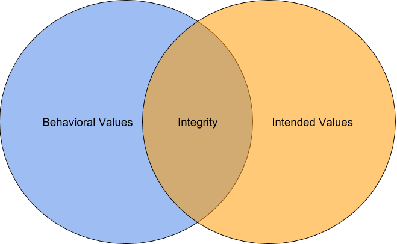

Integrity = Overlap of Intention and Action

The closer our behavioral values represent our intended values, the more integrity we produce for ourselves.

## 5.2 My Moral Beacons and Role Models

I have always learned to be a better person by the quality of my company. Those I most admire are those I most stand to learn from. There is something about everyone that I can admire and want to copy and assimilate into my being. I have simply too many role models to list, but I can attempt to list the categories of those people whom I admire.

- Immense, Raw Empathy
- Absolute Kindness
- Humility
- Generosity
- Strong-Heartedness and the Moral Courage to Act

Those same categories I list for my role models, are those traits that are the largest delta growth opportunities for myself. As I said before, I have learned the most and am immeasurably grateful to those people who had the courage to "set me straight". I often feel that I behave in cocky, cold, and lukewarm way. All of my role models have rock solid integrity; they act in the way they believe they should and have the "Heart of a Lion" that drives them to be true to themselves.

## 5.3 My Moral System: How I want to act

### 5.3.1 Touchstone Principles

#### 5.3.1.1 Royal Law

The biblical passage:

> Love thy neighbor as thyself

> Love the world as your self; then you can care for all things.

This is a manner of living where you value others success just as much as your own success. That you would take care of your neighbor in the same way you would expect to be taken care of.

#### 5.3.1.2 Expedition Behavior

On many of my trips with CRMS, our staffers often read the rules of expeditionary behavior. The most common, and most humorous, list is by Howard Tomb, summarized below.

> 1. Get the hell out of bed.
> 2. Do not be cheerful before breakfast
> 3. Do not complain
> 4. Learn to cook at least one thing right
> 5. Either A) Shampoo, or B) Do not remove your hat for any reason
> 6. Do not ask if anybody's seen your stuff
> 7. Never ask where you are
> 8. Always carry more than your fair share
> 9. Do not get sunburned
> 10. Do not get killed

These are very glib, but they get at heart of what expeditionary behavior means. It is a focus on putting the group above yourself. If you want to survive an expedition you need to rely on your team.

We were read this on my first outdoor excursion, Wilderness Orientation. On that trip I felt deeply ashamed that I was holding the group back. I swore moving forward that I would never weigh down the group. It meant being cheerful when the cards were down, and stepping up to do more for the group when the call was made.

#### 5.3.1.3 Utilitarianism: Minimize Harm

For me, utilitarian ethics are the safety net of determining the moral thing to do. By assigning numerical value (a crude approximation at best) to different outcomes it allows us to gauge a moral crisis decision point in an "objective" way.

At the end of the day, when none of my values can give me the clarity I need to make a decision, I rely on the brutal calculus of maximizing social good, and minimizing social pain.

### 5.3.2 Moral Compass

Taking all of my touchstones into account, this section asks me to define what I value, to solve that hardest problem of how to prioritize my moral values and make me realize just what I will never give up.

#### 5.3.2.1 Ethical Value Ranking: Intention vs. Implementation

When I look at how I rank Josephson's core values, I get the following:

1. Justice and Fairness
2. Caring
3. Responsibility
4. Respect
5. Trustworthiness
6. Civic Virtue and Citizenship

But when I meditate on my behavior I realize that I often rank "Justice and Fairness" below Respect, and shift everything up. This is representative of my most fundamental area for growth: Moral Courage.

After taking Ben Sands values finder, I get the following for my "Most Important Values:

1. Concern for Others
2. Humility
3. Belonging
4. Prosperity
5. Responsibility

and for my "Top Values by Behavior":

1. Humility
2. Belonging
3. Concern for Others
4. Loyalty
5. Achievement

Scratching off "Achievement" as an amoral value, I get that the way I act is deeply focused on others.

I have in my head this set of consistent guidelines for ethical behavior, yet in my actions I often let things slide. I stumble consistently off my moral path. I find that I often have so much care for others, so much loyalty, so much need for belonging that I don't stand up for my beliefs when I hear the call. I have too deep a need for approval by the group for me to act consistently on the standards I have set for myself.

### 5.3.3 Moral Code: Specifics

Distilling my moral compass into habits, strategies, and behaviors, I get my moral code. The day to day tactical decisions I make in order to act according to my values.

#### 5.3.3.1 Duty to Act

First, I have a duty to act when I see no one else acting. I abhor being a bystander. Even if it is awkward and even if it proves unnecessary I should, on habit and instinct alone, lend a helping hand.

When it came to the parable of the Sadhu, I felt like I had a moral obligation to help him down the mountain. Even if it cost me my trip. I might have been upset to break my plan, but it doesn't matter. On the day to day basis, I feel a direct obligation, a moral duty, to help those who are in need.

I don't assume this of everyone, and it is a lot to assume of myself. Many other people around me may be struggling with their own issues and be unable to help. This is not a categorical imperative for the world to follow, this is a principle in which only I hold myself accountable to. The benchmark is only for myself.

**If I see someone suffering under injustice or difficulty, and I do not help (thinking someone else will), I am complicit in that suffering**

#### 5.3.3.2 Do not be a burden

This follows from my first point. The people around me, and I've learned this from experience, are dealing with issues so much more intense, traumatic, and fundamental than mine. When I am upset with my life, or just feeling in a funk, I think carefully of who I want to share this with. If I can deal with it alone, then all the better.

I am not saying that I shouldn't share, only that I want to follow that spirit of expedition behavior. Unless it is absolutely necessary, don't complain. In the terminology of wilderness first aid, "Don't create another patient".

**Do not be a burden on others. It is healthy to share and connect, but do not over-rely on the emotional and physical labor of others**

#### 5.3.3.3 Be kind

This goes without saying. It takes so little of me, and helps others so much, to be a warm face, a deep hugger, and an attentive listener.

**Be nice.**

### 5.3.4 Moral Code: Exceptions

I do find exceptions to this code, however. Moral action is a melange of intention and implementation. While my moral code has focused so far on the happy path, it must be tempered by exceptions.

#### 5.3.4.1 Minimize Harm

If what may seem like moral behavior along my code is actually doing harm, then I should not do it.

If I am harming myself too deeply by not sharing my struggle, if I am too quick to "help" without understanding the nuance of a situation, or if my attempts to be "nice" to someone bolsters their confidence to perform hurtful actions, then my actions are not helping.

Thus the heuristics of my moral code must be balanced by the consequentialism of my utilitarian ethos.

#### 5.3.4.2 Respect Autonomy

The other exception is actually a subset of my goal of minimizing harm, but relates to a more fundamental respect for the autonomy of others.

Just as someone of sane mind has the right to refuse emergency medical services, so too do they have the right to reject my assistance. When my "helping" is felt as smothering and patronizing, I know I have gone too far.

## 5.4 My Character: How I actually act

My character is built from fundamental traits and principles. Many of these are strengths, and many of my strengths have shadow sides from their logical terminus. Here I try to list those that are indeed fundamental to my core character, those principles I live and die by. This is where the rubber meets the road, and all those fancy principles face the reality of my actions and the weakness of my humanity.

### 5.4.1 Where I am most proud

First we start with the good news, where the overlap of intention and implementation have seen the most integrity. These are the results of my moral behavior that I am most proud of, the best habits and results I have made from acting as I should.

I despise to self-aggrandize so these will be curt, bulleted lists.

#### 5.4.1.1 Generosity

I am most proud of my generosity in time, emotional labor, and money. If I am called upon by anyone in need

- Taken many hours to help those struggling with class assignments
- Brought food and gifts to sick friends
- Always made time for others when they need to confide in me
- Consistently pick up hitchhikers
- Consistently give money or food to panhandlers
  - And if I am unable always treat with respect and humanity
- Consistently donated to effective causes (GiveDirectly and Malaria Initiatives)

#### 5.4.1.2 Warmth

Next, I am deeply proud of my warmth and kindness. I feel that I am loved by my peers for my smile, hearty laugh, and joy. I'm deeply happy to be a source of warmth and affirmation for my friends, family, and countrymen.

### 5.4.2 Where I fail to measure up

But now we must cover the bad news, where the implementation lost track of my intention. Where I lack the most integrity. These are where I stumbled most, the worst parts of my moral behavior, and where I am still deeply ashamed of.

#### 5.4.2.1 Moral Courage and Honesty

I consistently feel uncomfortable standing up for my values in many of my personal relationships. I consistently fail to be honest when it comes to disappointing someone I care about. In many social groups, I find myself being a value chameleon, camouflaging myself to fit in with the dominant ideology. It is so fundamentally hard to rip the band-aid, get it off your chest.

I am king of the white lie. This is the shadow of not wanting to be a burden. When I know that knowledge of something will hurt someone, I will lie, and it kills me. It kills me to betray their trust. It kills me to laugh off hurtful language said by a high school friend. It kills me to maintain a facade, yet I once again lack the moral courage to hurt them. Tony said it beautifully in class:

> If what you need to do will hurt someone, you should expect to feel some pain yourself...

Part of what prevents me from coming clean in these situations, is that value of loyalty and belonging, my pathological need for approval. I perceive the damage that will happen to a relationship and rather than choosing the path of strength, that preserves my integrity and centers me on my values, I choose the path of weakness, that fractures my core and breeds shame.

This is so fundamental a problem, and I don't know how to get better at it. I only feel the damage I do to myself when I act in this way.

The only strategy I know of is to build my moral courage like a muscle. To start it off slowly with minor skirmishes and confrontations, test it and stretch it, until it can hold its own in the wild. I so deeply want to be a stronger person, to have that "heart of a lion" that I admire so much in others. I am agape to how they built that strength.

I am aware enough to realize that since my community affects my values, which in turn affect my behavior, that my community determines my behavior. I need to find people who challenge me to be better, who won't accept a George without the requisite integrity.

Even if I am so ready to help others, so eager to break the barriers in front of other's success, how can I help them when I am incapable of speaking truth to power, of being the shield to others who were given so much less than me.

I only know those barriers on the way to moral courage. I know that while I still seek out the approval of others with such fervor that I will never reach that point. I know that while I place the health of a relationship unilaterally above my moral fiber I will never reach that point. I know that while I maintain a lie, even superficially, so that someone's feelings will not be hurt I will never reach that point.

**When I die, do I want my eulogy to say "He was a nice guy, loved by all" or do I want them to say "He acted with integrity, resolute and steadfast for what he knew was right"?**

# 6 Amoral Fiber

## 6.1 Master your Craft

I mention this in my life mission, but it's worth going into why I value mastering my craft.

Making things feels good. It's visceral. The satisfaction at making a desk with your hands and your tools. The joy of getting my system set up to convert this leadership map from plain text documents into the format you see here right now. Making things, even better if they solve a problem, is a shortcut to direct achievement and satisfaction.

I've made some cool stuff in my life:

- EMP generator that can shut off small electronics.
- Standing desk from pallet wood for my freshman dorm room
- Programs to help my classmates with grunt work on our final projects
- Papercraft masks for Halloween
- Metal and glass flower pot sculpture

These fulfill my creative urge. Literally the desire to create, but also the desire to express myself.

I've always enjoyed making things; I'm not sure where it originated. I can't remember a time when I haven't enjoyed manipulating physical medium. Even in grade school my art projects existed in physical space, penny nails on a wood board adding texture to a water color.

When it comes to mastering my craft, I feel there's also an element of recognition from my peers. I love making a creative product but the icing to this cake is that community validation that comes from making something people value.

## 6.2 Learn, Learn, Learn

Reportedly, this was the advice Lenin gave to young people, and it holds true today. I have a deep curiosity and hunger for learning. It feels so good to grapple with a novel concept. I enjoy more than anything sharing my knowledge with others. I love seeing the glint of clarity and understanding in someone's eyes just as much as experiencing it myself.

Beyond academic learning, I value self-knowledge. We hearken back to the words of Socrates:

> The unexamined life is not worth living

The benefits of self-awareness are many. To live in accordance with your values, you must first know your values. This is not to say that I am a very self aware person. Like so many areas of expertise, the less you have the more likely you are to overestimate your ability. Suffice to say, I am just on the cusp of self-awareness, enough to realize all the work I need to do.

## 6.3 Being Less Wrong More Often

### 6.3.1 What this means

I value having true beliefs.

This may sound odd, but I believe it is important that my understanding of the world is correct to the best of my ability. It presupposes the existence of ground truth (because, lets be honest, we wouldn't look both ways at crosswalks if we thought truth was completely subjective). If there is ground truth out there, then why should we not try to shape our beliefs to be closest to reality?

## 6.4 Shortcoming: Developing Discipline

An amoral virtue I feel the need to cultivate is that of Discipline. So much of the success, curiosity, and passion that drive me are fickle in their source. They could not carry me through a winter. They are useful tools but are capricious. Discipline, for me at least, is an undeveloped muscle. I often fail to hold myself to deadlines, to do what I said I will do by the time I said I would, and when the going gets tough to be tough enough to keep going.

If I could be more disciplined, I would be better able to manage my time and accomplish the goals that matter to me when passion for them is no longer enough to see it through.

# 7 Leadership Qualities

I am not a driver. I am not a dictator. Where I excel is in motivating others, and in helping people remove their blockers. In this section I hope to elaborate on the ways in which I am best able to lead and those areas where I can most stand to get better.

## 7.1 Lead from the Rear

I feel most comfortable doing what I call, leading from the rear. It means listening to your squad, understanding where they want to go, and helping them realize the path to their success. It's flipping the script on traditional leadership. Instead of the team depending on you, you depend on your team. Instead of leading your team, you follow them, and enable them to achieve the success they determine. This is not control, this is trust.

## 7.2 Lead by Example

I feel at home in the trenches. I'm detail oriented in the extreme. In that same way that I love the craft, I love being on the front line with someone on my right and left working on the problem. I'm a poor delegator, but a good doer.

The way I lead is by setting the high water line of what work should be. If you want your community to act the way you want them to, you must first act the way you want them to. If you set the standard, others will follow.

## 7.3 Implementation: P-WILD and Non-Directive Leadership

Twice a year, for every year of my Undergrad, I helped with a program called Project WILD (Wilderness Initiative for Learning at Duke). On August we take groups of 7-8 incoming freshman and 2-3 staffers. On March we take 3-4 crew members and 2-3 staffers. Over two trips as a participant, and 6 trips as a Staffer. The primary leadership style, the high water mark, was non-directive leadership.

Let's unpack that term. To be non-directive is a combination of these leading from the rear and leading by example. As a staffer, you have a fundamental expertise of the problem domain. You've been on these trips, you know how to rig a tarp and cook a meal in the woods. You are a resource for these crew members, but they can easily come to rely on you. The goal of a non-directive leader is to build your crew's competencies to the point they no longer need you. This a difficult path to thread, as you need to balance support with challenge. The crew needs to learn, and in order to learn they need to suffer. If you always act as a safety net for your crew they will not learn the skills they need to become good staffers in turn. Programmatically this means they make the same mistakes we did as crew members, but we learn best from our own mistakes.

## 7.4 Sheep vs. Goats

My approach to leadership can be illuminated by a metaphor:

> “The merest accident of microgeography had meant that the first man to hear the voice of Om, and who gave Om his view of humans, was a shepherd and not a goatherd. They have quite different ways of looking at the world, and the whole of history might have been different. For sheep are stupid, and have to be driven. But goats are intelligent, and need to be led.” - Terry Pratchett

Let me elaborate and interpret this statement. Mild disclaimer, I know nothing about the actual animal husbandry, so please take this metaphor with a block of salt.

### 7.4.1 The Shepard and The Drove

It is somewhat problematic to refer to people as sheep, but what I want to focus on is the approach of the shepherd. The Shepard drives the flock. Another name for a sheep collective is literally a **Drove**. What does this mean for the community. It means the sheep are driven by the stick. The sheep are in a state of stress, forced to move to the places the shepherd wants them to.

This is inherently against my strengths. I don't have a vision of where we should go. I don't have the will to force my team in the direction I choose. I am more of a goatherd.

### 7.4.2 The Goatherd and the Tribe

Goats are stubborn. They are smart. They know what they want and can fight to get it. The collective noun for goats is **Tribe**. These are my kind of people. Goats cannot be driven, they need to be influenced. There is a trust in the tribe, and not every team will have this. The goatherd is a member of the team, in service to the team.

## 7.5 Growth Opportunities - Trade Offs of Gentle Leadership

There are deep trade-offs in this approach though. As a technical leader in the trenches, I can lose the forest for the trees. It prioritizes tactics over strategy. And it depends fundamentally on the mutual trust of you and your team.

I feel that I am passing the buck on taking a stand. This style of leadership is go with the flow; the tree that bends survives the hurricane. What should I do when the time is not to bend but to hold fast, to double down on what matters?

## 7.6 Growth Opportunities - Personal Competency Worksheet

After filling out my core competencies worksheet, I found the following areas needed the most development.

- Taking action, making decisions, and following through
- Managing conflict and negotiating
- Time management

Notice a theme? I find that I too often bend when I should hold steady. I need to learn to hold myself and others around me more accountable. Planning my time so that I am more equipped to follow through on my commitments is fundamental. I need to be true to myself and true to my word. I've mentioned this before, but I am a deep people pleaser, sometimes at the cost of my own integrity. This needs to change.

# 8 Twenties Journey: Objective, Direction, and Path

It may seem paradoxical, but I am simultaneously sitting at a pivotal moment and given a set of, in the long run, meaningless choices. The values I build and cement in the first chunk of my adult life will stay with me as I move forward. In the words of Joseph Campbell, as I join the adult world I switch from a relationship of dependence to a relationship of independence, and finally to a relationship of people depending on me.

I am 23, having spent my last 23 years in the education system, with only a brief foray into working as a coop employee (6 months) and interning (2 months). I have 8 months of reasonable adult experience. I sit at the precipice of a sea change, a complete shift to self reliance where I no longer depend on my parents income nor the communities built up by my schools and childhood interests. This is a defining decade for the man I want to become.

Yet I can't help but remember Robert Frost's poem, "The Road Not Taken". The poems protagonist comes to a fork in the road, and chooses a path. In what is perhaps the most misunderstood poem in American popular thought, the meaning of the poem is not that taking the road less traveled made all the difference, but that the protagonist is rationalizing the future impact of what seems like a weighty decision. The choices I make for my first job or city. Many choices turn out to be irrelevant stumbling blocks on my path. Often these choices seem deeply important in the moment, but looking back we see, with a little more objectivity, that these made no fundamental shift in our perspectives. We can only connect the dots looking backward.

## 8.1 Aspirations

With all this in mind, I cannot say that I have strict goals for myself when and if (God willing) I hit thirty years old. My metrics for success, happiness, and meaning in my twenties are much similar to my metrics so far but of a pivoted focus. I mention my aspirations not as goals per se, but as touchstones of meaning that I will chase for the next 7 years, and beyond.

### 8.1.1 Find a Community

This next period in my life I am moving from a position of hustling within the communities of my schools and family, to those entirely new of work, and city, and random happenstance. It is a watershed moment, for the communities that I find and make my place in define my behavior and my behavior defines my values.

The question is what do I want out of my community? The same I have wanted out of my Duke and CRMS communities. Now, no one community will fit all of these criteria, and so it will be up to me to make time for a mix of those groups that will add up to where I want to be.

- Seek to help each other
- Inclusive Culture
- Challenge and improve each other
- Widen my perspective
- Camaraderie, or shared suffering/stakes

I want a (gender-neutral) brotherhood. I can rely on my community and they can rely on me in turn. These people bring out the best in me. I will break down how to find these communities later, but even this problem definition should not be considered solved. The question of what tribe I should belong to is intertwined with the question of who I want to be. The communities I belong to could make me stronger but colder, or warmer but weaker, or yet some non dichotomous combination of everything.

**The higher level goal of finding a community, is that by surrounding myself with good people, I in turn am called upon to be good myself.**

### 8.1.2 Professional Development and Recognition

As mentioned many (perhaps too many) times in this map, I want to do good work. It's even better if I can be recognized by my peers that my work is good. It just gives me butterflies to have my work appreciated. I mean, this stuff is dreadfully obvious, unnecessary to say even. The question here is how to balance personal satisfaction in my work, external evaluation of my work, and time investment taken to complete it. I value achievement, and in a work environment that short-circuits my brains rewarding logic, I could easily overwork or over-prioritize achievement in my twenties. It would be exceedingly easy for me to put my head down, work hard, and wake up 7 years down the road, even having made it "up" the technical ladder, but having made little to no progress on the other goals that I value.

Working hard may be difficult, but at the end of the day it is simple. That simplicity makes it attractive as a refuge from the complexity of social interaction or value clarification that will round out and mature me in needed ways moving forward.

## 8.2 Strategies

### 8.2.1 Master my Craft

I have the tools in my repertoire to get better at my craft. I have spent the past 4 years becoming a better programmer and engineer. I will spend the rest of my working life building and developing my "hard" skills. I love to read technical manuals and textbooks. These strategies are, in my opinion, **boring**, but I'll quickly list them out for completion.

- Keep pace with current technology
  - Read about cutting edge practices
  - Attend conferences and engage with other experts in the field
- Seek out mentors
- Aggressively seek and incorporate constructive feedback
- Refuse to coast, always be improving your skills

### 8.2.2 Prioritize Health

By the time I am 30 I want to be able to:

- Squat 300 pounds
- Dead-lift 400 pounds
- Do ten pull-ups in a row
- Be able to run 5 kilometers

Currently I am:

- 280 pounds, at least 100 pounds overweight for my height
- unable to do a single pull up
- unable to run any sizable distance
- Able to, at my most, move weights of 150 pounds.

These are instantly measurable, and reasonably achievable. I mention these first since I find it so easy to let myself slunk from my goals. To settle for less than what I wanted.

For the past 23 years, I have let my health sour as a trade off for academic and social goals. This is simply unsustainable. I have my youth now to hide the effects of my poor fitness under my young *joie de vivre*, but that will age as I do. I want to live a good life. That means I need to have the energy and liveliness to tackle my day at any age. It comes down to Newton's Laws, an object in motion stays in motion and an object at rest stays at rest unless acted upon by another object. When I see the quality of my life in the next ten, twenty, forty years I begin to see the negative effects my health will produce in me. I am wasting my potential if I do not get to a minimum level of health to see my goals through to the end. I can do so much more good if my life is not 30% shorter.

### 8.2.3 Widen my T

Sitting in a dark room, rapidly typing at a keyboard while music plays on my headphones is, no doubt for me at least, a fun time if I'm working on a cool, difficult problem. The issue is that this is only improving my depth of ability and not making a fundamental shift in my competencies. Retreating to an ivory tower to emerge with a program that elegantly solves a novel problem is my meat and potatoes. It's my candy.

I need to eat my vegetables. If I want to supercharge my ability to make waves in my career, and tackle problems outside of the workplace, I need to develop skills in other areas. The buzz phrase is "widen my T", but what this means is that outside of my ability to solve technical problems, I need to learn how to interact with customers, what questions to ask that isolate the problem they face, so that I can be better equipped to solve their issues.

I need to be better at the soft (but still absolutely difficult) skills of people management, interaction, and negotiation. In turn, I hope this wider skill-set can give me the power to make key benefits outside of my career for the things that I most value.

# 9 Implementation: 3-year plan

The next three years pose some interesting opportunities to me, and by (completely random I assure you) happenstance turn out to be the longest I am capable of planning.

Before I break down my mission statement, It's useful to break down the opportunities coming in the next three years

- My first job as a data engineering focused programmer
- A brand new city with a sizable young population, Charlotte
- My girlfriend who is also going to be working in that same City
- Transition to having more free time by a clean separation of working and non-working life.

In many ways this is like my previous work experience, indeed I took a semester off before to work full time. I prototyped what it meant to be in a new town away from my school, to deeply miss my friends from university, and to shift my perspective around work so that I would not burn myself out overworking.

It's different now, I am placed before sprawling choices:

- How long should I work at my first job?
- Should I pursue higher education?
- Is my current romantic partner the person I want to spend the rest of my life with?
- What communities in Charlotte should I try to carve my place in?
- Is Charlotte even the right place for me?

This problem space is so open that I lack the computational resources to find even locally optimal solutions. I must fall back on my values. I know that if I make my decisions based on an honest evaluation against my values, that I will not regret my choices made in these first three years out of school.

## 9.1 3-year Mission Statement

For my first three years out of school, I want to:

1. Begin and develop authentic connections with my coworkers and new friends in Charlotte
2. Maintain and develop those connections I have with my inner circle at Duke, in my family, and with my girlfriend
3. Learn and grow as much as I can as a software craftsman
4. Pivot from my intense focus on academic achievement to make benefits for the communities I find in Charlotte as well as my personal health

This distills down to the life-mission of community and craftsmanship, but it adds a focus on fitness as an enabler for both of these.

## 9.2 3-year Success Kaleidoscope

3-year success kaleidoscope

Identity Group

Happiness

Achievement

Significance

Legacy

Self

- Fitness
- Fitness

N/A

N/A

Family

- Connection

Work

- Connection
- Craftsmanship
- Craftsmanship
- Craftsmanship
- Craftsmanship

Community

- Connection
- Benefits
- Benefits

## 9.3 Leadership Development Objectives & Key Strategies

The objectives are relatively self evident from the 3-year mission, but there are many strategies that represent the opportunities I have in my move to Charlotte.

### 9.3.1 Strategies to Find Connection in Charlotte

1. Join user groups and meetups (i.e. professional development communities in tech)
2. Find communities of shared interests (board games, maker-spaces, public gardens, etc.)
3. Engage with the Duke network in Charlotte
4. Authentically relate to my coworkers, going out of my way to make friends with them beyond the workplace.
5. Make friends of my friends' friends (i.e. leverage their networks)

### 9.3.2 Strategies to Build my Fitness in Charlotte

1. Go to spin classes with my girlfriend
2. Find a friend that is interested in pursuing fitness to keep each other accountable
3. Prepare meals in advance to better portion sizes, save money, and make more time to be with friends on week nights.

### 9.3.3 Strategies to Make Benefits in Charlotte

This deserves to be a little meatier than the other strategies. I am in the extremely lucky position to be employed by a company that cares about making local benefits in Charlotte. I can leverage their connections to non-profits in the area and make benefits for them using my skill-set. So many groups have amazing knowledge and expertise of the problems facing them, but lack a quantitative skill set to store and handle their data. My company would provide me with expertise and advice on how to serve these organizations in my own time.

This strategy hits a lot of my success kaleidoscope: Benefits, Connection, and Craftsmanship (Win, Win, Win).

### 9.3.4 Strategies to Be a Better Craftsman at Tresata

1. Take advantage of my mentors at Tresata (a small, vertically integrated company)
   1. Debrief the design choices of their system from the original architects
   2. Learn about interacting with customers from the product team
   3. Learn about the care and growing of a startup from the founders
2. Help others in their technical blockers wherever possible
   1. Mentor interns and new hires come the new wave in summer

## 9.4 Key Issues, Decisions, and Plans

### 9.4.1 Working at Tresata

While I am deeply excited and enthusiastic about my upcoming Job at Tresata, there are key issues with the position. First, the compensation seems low for equivalent work. The perspective from HR is that Tresata is a "meritocracy", which is a red flag for me at least. Although it is not entirely true for my team, the development team, the office is expected to be present from 8am to 6pm (10 hrs) every work day. This may mean a culture of overworking, but it may mean a close community within my office. From what I can tell, many of my coworkers routinely stayed late some evenings, but was this so bad? Many employees came in between 9 and 10 in the morning.

The company culture at Tresata will be of decent importance to my next 3 years, so understanding how I will carve my place in a way I can personally sustain is fundamental to my success moving forward.

### 9.4.2 New City, New Community

The next big issue is how to find connection in Charlotte. I have my work, the Duke community in Charlotte, and my girlfriend's friendships as networks. I will want to capitalize and find connection within those, but these each provide an individual, perhaps biased, sampling of the underlying population. If I am to seek out groups that challenge me to be a better person, I need to seek out communities with the values I want to develop.

Charlotte, for lack of better words, seems *yuppie*. I know that if I don't seek out the right people, moral people who challenge me to be more strong hearted, I could slide into alright friendships with alright people. This is not a moral judgment on those with other priorities. This is not a condemnation of those who value corporate success as a primary goal. I only hope that I am able to find those intentionally moral people that I have had the unique pleasure of meeting here at Duke. We are all crooked timber, but I hope that I can find others whom I can help and be helped in turn to stumble toward betterment.

### 9.4.3 If and When: After Tresata

With these in mind, I have to understand what is to happen at the precipice of my next 3 years. This is extremely hypothetical, but there may come a time when Tresata is unsustainable for me to continue working. After this point, what should I do? I think I have a few options:

- Education
  - Business (MBA)
  - Technical (masters or PhD)
- Work
  - Private Sector Tech Company
  - A Non Tech Company in a Technical Role
  - Government Agency
  - Academic Research

Each of these has their own trade offs, and I am not at a place right now where I can know what choice I would make. I can, however, speak to the difficulties that would present when making that decision. In this choice I would be trying to optimize across being close to my family, challenging myself in my work, and how to hold on to the companions I build along my path.

# 10 Implementation: The next 3 seasons

Now we come down to brass tacks. Here I will outline the strategies and opportunities to face in my last semester at Duke and my move to Charlotte in the Spring. I identify in the coming seasons is a process of refinement, expansion, and refinement. I hope to focus in on my classes and friends at Duke. Expand out to my work and new communities in Charlotte.

## 10.1 Fall 2018

I write this section as of early November. I have two months, perhaps one real month, left in my undergraduate career. I see, in not uncertain detail, how they will lay themselves out. I feel, not a melancholy, but a nostalgia for my Duke career. I will deeply miss the connections I made here, but I'm happy to be moving to my next step in life.

The question at hand, is what will make an excellent last semester at Duke. Going into this semester, I wanted to see what I was capable of. I am part timing, and I wanted to see how much I could learn if I put myself to it. I found this unsustainable and perhaps learned my lesson. I need to be deep not wide in my last month at duke. I need to tie up loose ends and try to maximize my connection with my friends. I need to be a good housemate, a good friend, and a good student in my last two classes. It is so easy to go wide here at Duke, to try and take on so much responsibility, but I have been enamored with those semesters where I wasn't stretching myself thin, where I was focused on the people around me.

**My strategies for this last month are to do deep work in my classes and maximize my time with my friends.**

## 10.2 Winter 2019

This is when my work starts. January 17Th is my start date. I want to hit the ground running. The first two months at Tresata I will be a part of their on-boarding and training program, which will give me the time to build up my skills and make productive contributions.

In order to best fulfill my goals, I want my days at Tresata to be broken down as follows:

- From 8 to noon I will work
- At noon, for an hour I will use the company gym (hopefully with a coworker)
- At 1 pm I will take lunch with my coworkers
- from 2 to 6 pm I will work

Outside of this, I would like to take this time to probe the networks available, get a sense of what the people are like in town, and see what communities I would best fit and thrive in.

**In the first season of my career, my goal is to expand into the role of a good software craftsman and survey the available communities in Charlotte**

## 10.3 Spring 2019

The spring is predicated on the winter. I hope that by this point I will have made strong friendships with my coworkers, my Duke alumni network, and at least one tech professional or learning group.

After the winter of expansion, I want to see what pans out. That may seem glib, but I mean it closer to the literal interpretation of the word "pan". My winter should be spent surveying the land and gathering sediment, putting in the work to mine relationships from the awkward territory of acquaintances.

**The spring will be a time where I can pan out the sediment and search for those golden nuggets: people I mesh with, who challenge me and help me and I help in turn to be better.**

# 11 Closing Comments and Reflections

I hope that after reading my leadership map, you have a better understanding of the circumstances, decisions, and frameworks that have guided my life and made me into the man I am today.

There are certainly things in this map I did not include for lack of my own memory, space constraints, and (in some instances) issues too personal for inclusion in a publicly available paper. If you notice one of these areas, I welcome you to seek me out and drill down on this in private conversation, as I would be happy to share one on one.

This also applies if you find that you relate to my story and have some useful advice on how you gained your moral courage. I need all the help I can get here.

Thank you for taking the time out of your day to learn a little about George. He's a work in progress, but always with emphasis on the progress.